# PostgreSQL Integration with R

Jeremy R. Porter

February 12, 2020

####In today’s lab we are going to use built in integrations between PostgreSQL spatial database and R using the Rpostgres package. Once we have setup the database connection, we will be reading in data pertaining to recorded real-estate transactions. The data are part of a larger project looking the negative impact of sea-level rise on coastal property values. Today we are interested in creating a point file of 2005 observed values, interpolating those values via a simple IDW method, and sampling the interpolated values to a larger working dataset that we will use throughout the semester.

####First, let’s set our working directory for any files we may write from R….

```r
knitr::opts_chunk$set(
    echo = TRUE,
    message = TRUE,
    warning = TRUE
)
setwd("C:/Users/Jeremy/Desktop/Spring2020/AdvGIS/ADV_GIS/week 4")
```

####Next, let’s require the `RPostgres` pacakage (Note: for any package not already installed in your local environment, you should first `install.packages("[Package Name]")`)

```r
require(RPostgres)
```

####Using the `RPostgres` package, we are going to setup a connection with the postGIS database we have setup on our local machines. The setup process includes the creation of a new R object containing all of the setup information, `conn`. To create the `conn` object, we will use the `dcConnect` funtion to connect to `Postgres()` in the `RPostgres` package `(RPostgres::Postgres())`. Our database name is `advanced_gis`, the host is `localhost`, the port is `5432`, user is `postgres`, and my password is `jeremy`. Finally, I set the `digits = 10` to truncate any really long real numbers that are produced as part of the data transfer from Postgres to R.

```r
conn <- dbConnect(RPostgres::Postgres(), dbname = 'advanced_gis',
                  host = 'localhost', # i.e. 'your computer'
                  port = 5432, # or any other port specified by your DBA
                  user = 'postgres',
                  password = 'jeremy')


options(digits = 10)
```

####The next chuck of code is creating the R object `prop` using the `dbFetch` function which sends and `SQL` query to the Postgis database via the `dbSendQuery` function and the `SQL` query `select pr_sq_ft, fsid, saleyear, x, y from lab4.oc_prop` in order to extract th ID, year of sale, price per square foot, and lat/long from the `oc_prop` table in the `lab4` schema. The next few lines of code `plot` the data by lat/long `(x,y)` and explore the data for further use.

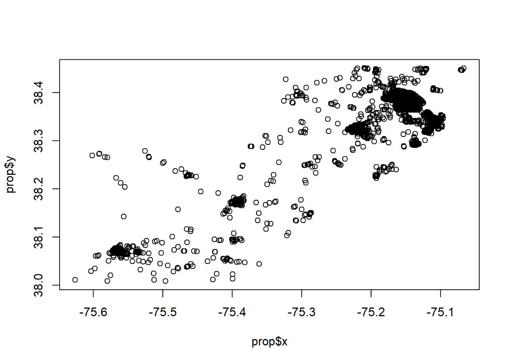

```r
prop <- dbFetch(dbSendQuery(conn, "select pr_sq_ft, fsid, saleyear, x, y
                                  from lab4.oc_prop"))

plot(prop$x, prop$y)
```

```r
summary(prop)
```

```
##    pr_sq_ft             fsid             saleyear
##  Length:5000        Length:5000        Length:5000
##  Class :character   Class :character   Class :character
##  Mode  :character   Mode  :character   Mode  :character
##       x                  y
##  Length:5000        Length:5000
##  Class :character   Class :character
##  Mode  :character   Mode  :character
```

```r
prop$y <-as.numeric(prop$y)
prop$x <- as.numeric(prop$x)
```

####Now that we have explored the data, lets limit the data to the most dense part of Ocean City, MD and use the `x` and `y` bounds to limit the data. Also since we will ultimately be interested in examining the impact of sea-level rise on home values, we need to first estimate a base value for home values in the region. Our models will ultimately start in 2005, so we create `prop_sub` as a subset of the ocean county data where the real estat transaction occured in 2005 `(saleyear=="2005")`. Finally, we plat the subset of 2005 data.

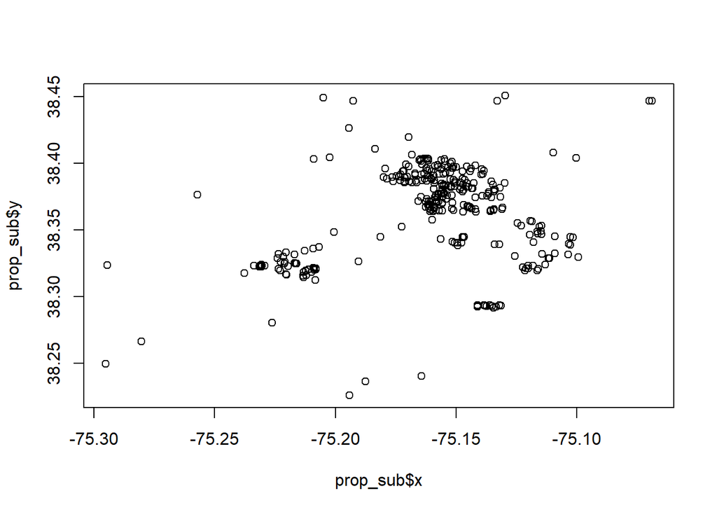

```r
prop_oc <- subset(prop, (y > 38.2 & y < 38.5) &
                (x > -75.3 & x < -75.0))

prop_sub <- subset(prop_oc, saleyear=="2005")

plot(prop_sub$x,prop_sub$y)
```

```r
head(prop_sub, n=10)
```

```
##            pr_sq_ft         fsid saleyear            x           y
## 1  436.451897616946 240472086092     2005 -75.13892612 38.39201732
## 2  436.451897616946 240472086092     2005 -75.13892612 38.39201732
## 12 112.203462278265 240472086102     2005 -75.23759339 38.31736968
## 13 112.203462278265 240472086102     2005 -75.23759339 38.31736968
## 14 186.396677050883 240472086103     2005 -75.23050758 38.32225619
## 15 123.142263759086 240472086103     2005 -75.23050758 38.32225619
## 17 169.376693766938 240472086104     2005 -75.20813291 38.32032130
## 20 188.470066518847 240472086107     2005 -75.16321038 38.39247534
## 28 204.430220883534 240472086118     2005 -75.11605033 38.34710954
## 29 204.430220883534 240472086118     2005 -75.11605033 38.34710954
```

####Before we interpoate the base home values, we should first examine the data to better understand if they are appropriate for interpolation (i.e. is there a significant spatial process). To do this we will need both the `gstat` and the `sp` package.

```r
#install.packages("gstat")
#install.packages("sp")
require(gstat)
require(sp)
```

####To test for spatial correlation, we are going to use a spatial variogram. The variogram method requires that we convert our `data.frame` object `(prop_sub)` into a `SpatialPointsDataFrame`. We can do this easily by using the function `coordinates` in the `sp` package and specifying which columns are longitude and latitude. To further explore the data visually, I also create a `bubble` graph of the price per square foot variable `(pr_sq_ft)` just to get a first order understanding of the potential spatial clustering.

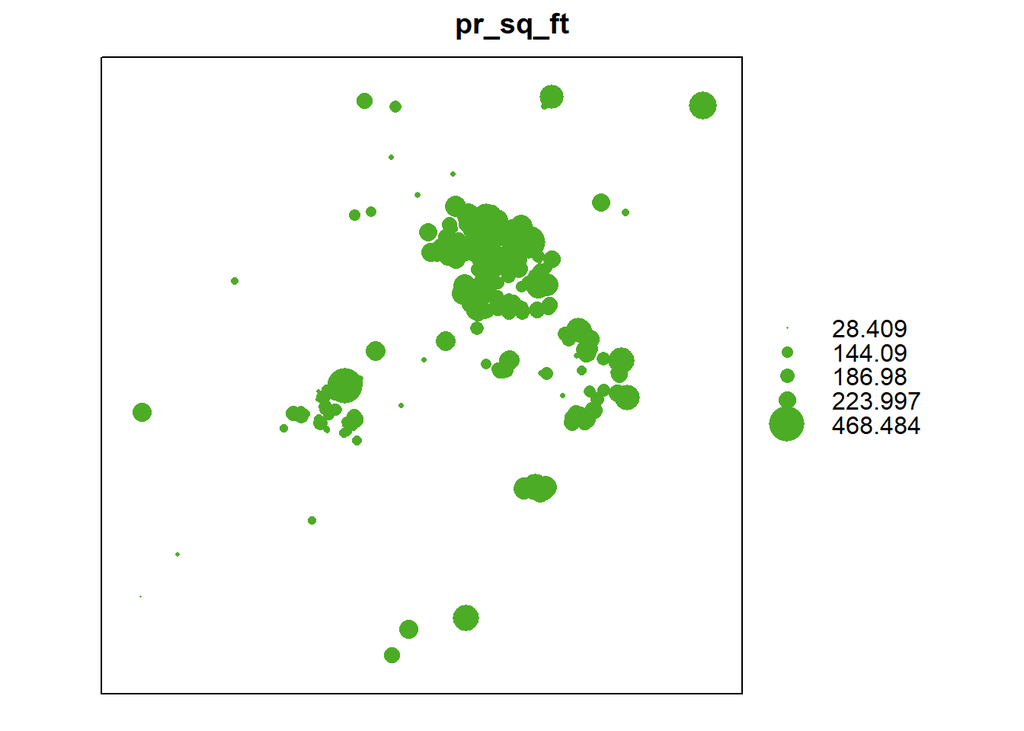

```r
coordinates(prop_sub)= ~x+y

prop_sub$pr_sq_ft <- as.numeric(prop_sub$pr_sq_ft)
bubble <- bubble(prop_sub, zcol="pr_sq_ft", fill=T, do.sqrt=F, maxsize=3, add=T)
bubble
```

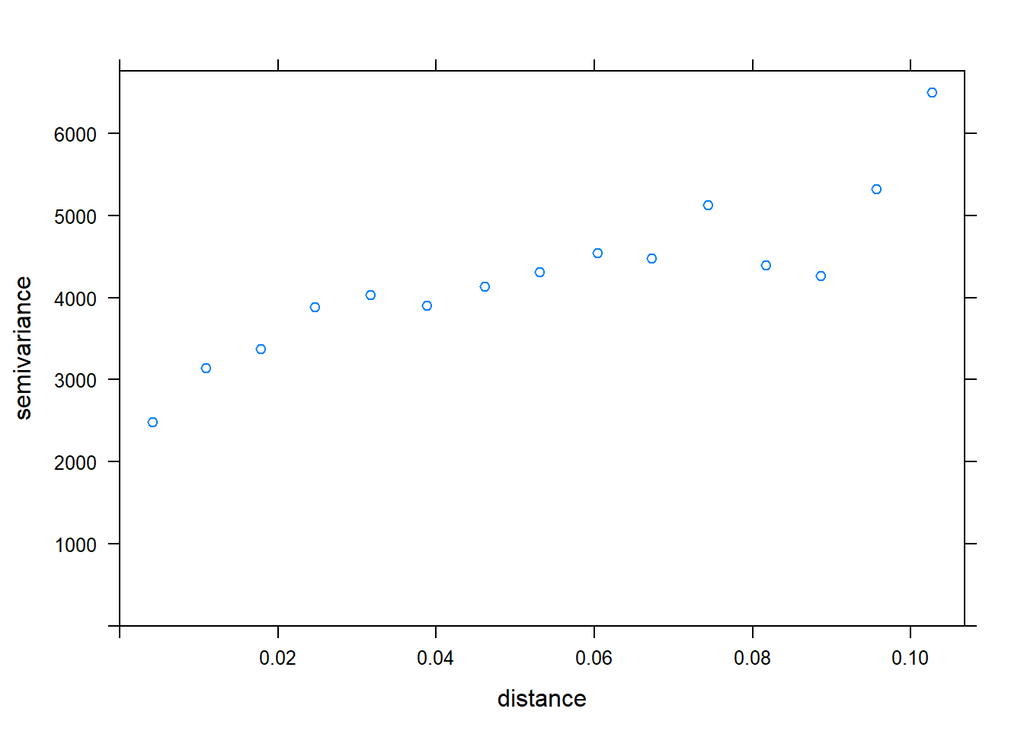

```r
prop_cor <- variogram(pr_sq_ft~1, data=prop_sub)
plot(prop_cor)
```

```r
prop_cor
```

```
##      np           dist       gamma dir.hor dir.ver   id
## 1  3596 0.004173448489 2483.317990       0       0 var1
## 2  6946 0.010861253716 3145.911239       0       0 var1
## 3  8662 0.017801807504 3376.299927       0       0 var1
## 4  8162 0.024706729773 3881.938333       0       0 var1
## 5  5992 0.031675120645 4031.105564       0       0 var1
## 6  4368 0.038771353359 3903.839640       0       0 var1
## 7  3767 0.046126409804 4130.374498       0       0 var1
## 8  3615 0.053049525743 4313.950526       0       0 var1
## 9  4011 0.060406002921 4540.340661       0       0 var1
## 10 4421 0.067259150603 4475.140805       0       0 var1
## 11 4711 0.074343679062 5122.469729       0       0 var1
## 12 5599 0.081650399579 4389.380584       0       0 var1
## 13 5973 0.088575457357 4260.190334       0       0 var1
## 14 5206 0.095633751249 5317.383966       0       0 var1
## 15 4421 0.102696259785 6498.488763       0       0 var1
```

```r
prop_cor_fit <- fit.variogram(prop_cor, vgm(c("Sph","Exp","Mat")))
prop_cor_fit$range[2]
```

```
## [1] 0.02334852953
```

```r
plot<-plot(prop_cor,prop_cor_fit,
           main="Variogram:\nDistance Threshold for Spatial Effect on Real-Estate Sales")
range_mi <- prop_cor_fit$range[2]*69
range_mi
```

```
## [1] 1.611048537
```

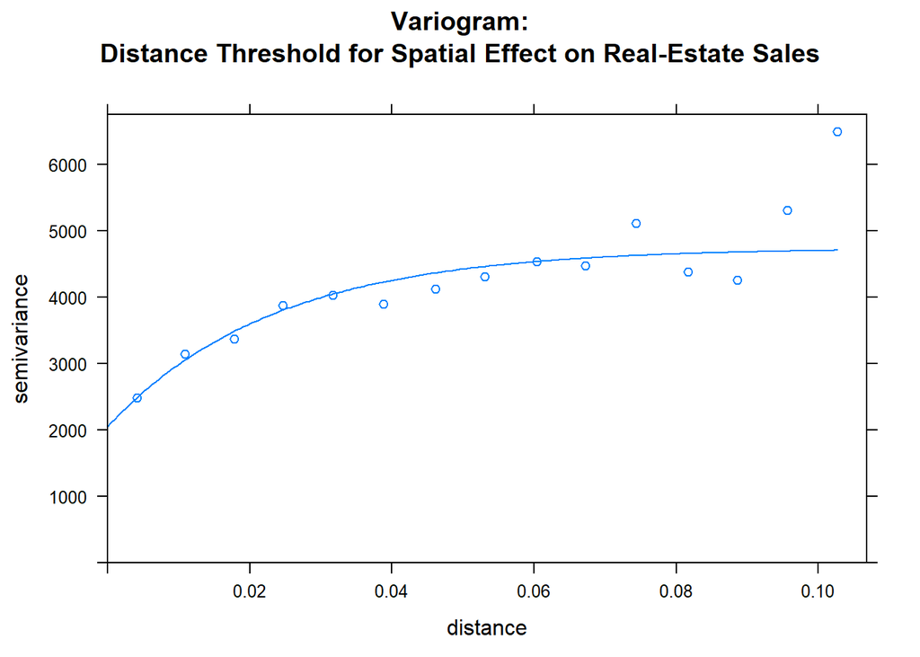

```r
plot
```

####Since we know that the data are spatially-autocorrelated, we can feel confident in interpolating the data… but to do so, we must first prepare the data for interpolation. The first thing that I am going to do here is create a new `grid` which is made up of `5000` points within the bounds of the original `prop_sub` object using the function `spsample`. This new grid is converted to a spatial object by identifying the `coordinates` and then converting the data to a `spatialpixel` `(gridded(grid))` and `spatialgrid` `(fullgrid(grid))` object. Finally, the new `spatialgrid` object is projected to the same projection as the `prop_sub` object `(proj4string(grid) <- proj4string(prop_sub))`.

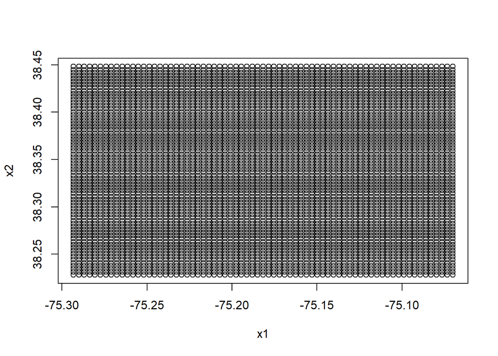

```r
grid <- as.data.frame(spsample(prop_sub, "regular", n=5000))
plot(grid)
```

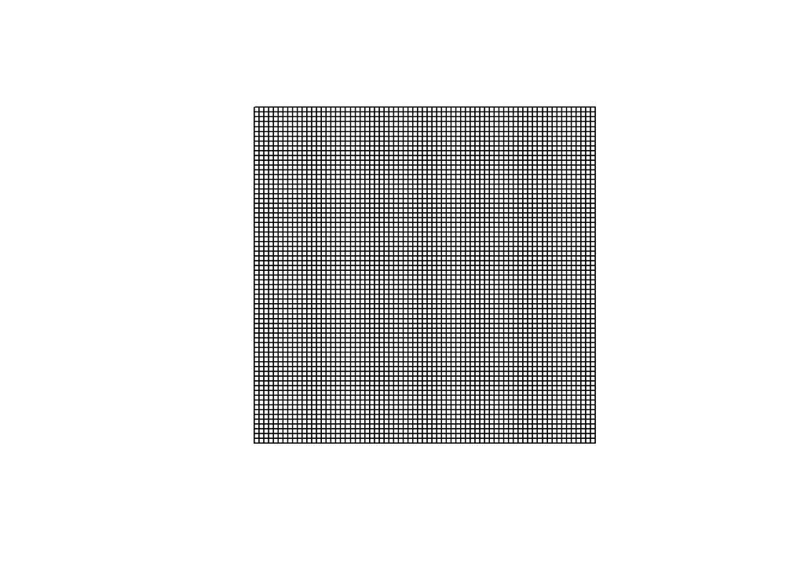

```r
coordinates(grid) <- c("x1","x2")
gridded(grid) <- T
fullgrid(grid) <- T
plot(grid)
```

```r
proj4string(grid) <- proj4string(prop_sub)
```

####Next the `spatialgrid` object `(grid)` is filled with values using the `idw` function in the `gstat` package. The new interpolated data will be an estimation of the Price per Square Foot `(pr_sq_ft)` from the `prop_sub` object using a 2nd order exponent on the interpolation `(idp=2.0)`.

```r
pr_sq_ft_idw <- gstat::idw(pr_sq_ft~1, prop_sub, newdata=grid,
                           idp=2.0)
```

```
## [inverse distance weighted interpolation]
```

####The result of the interpolation is a new raster which we can create by loading the `raster` package and converting the `IDW` interpolated `spatialgrid` object. Using the `raster` package ulities we can also `plot` our new raster file and overlay the coorindates that were used to create the interpoaltion from the `prop_sub` object.

```r
require(raster)
```

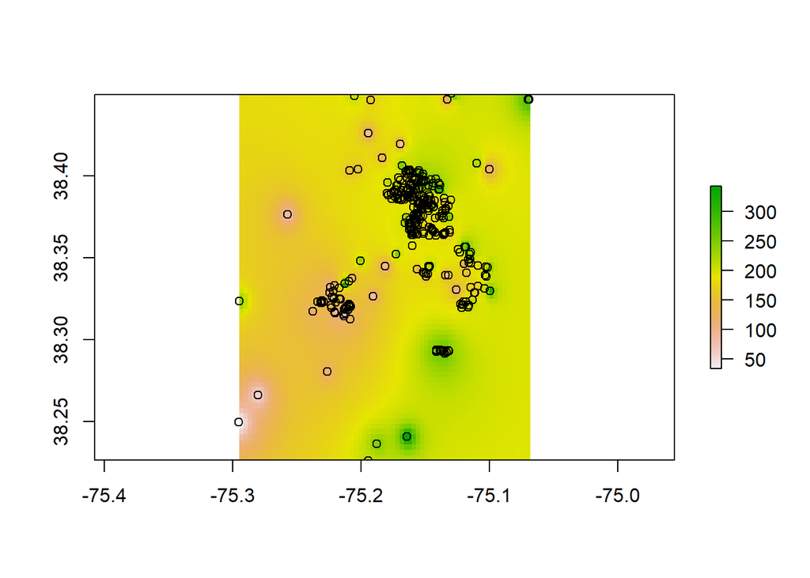

```r
raster <- raster(pr_sq_ft_idw)
plot(raster)
points(prop_sub$x,prop_sub$y)
```

####The last thing we want to do is `extract` the estimated 2005 property values as a starting point for the models we will run latter in the semester. To ensure that we have a starting value for all properties in our model, we create a new variable in our full dataset `prop_oc` that `extracts` the value of the 2005 value estimate to a new column in the dataset `samp_pr05`.

```r
prop_xy <- prop_oc[,c("x","y")]
prop_oc$samp_pr05 <- extract(raster, prop_xy)

head(prop_oc, n=20)
```

```
##            pr_sq_ft         fsid saleyear            x           y
## 1  436.451897616946 240472086092     2005 -75.13892612 38.39201732
## 2  436.451897616946 240472086092     2005 -75.13892612 38.39201732
## 3  225.694444444444 240472086093     2006 -75.16592039 38.38285553
## 4  124.710648148148 240472086093     2011 -75.16592039 38.38285553
## 5  124.710648148148 240472086093     2011 -75.16592039 38.38285553
## 6  211.236933797909 240472086097     2006 -75.16286912 38.36604107
## 7  211.236933797909 240472086097     2006 -75.16286912 38.36604107
## 8  171.102661596958 240472086099     2018 -75.17747846 38.39534681
## 9  198.669201520913 240472086099     2006 -75.17747846 38.39534681
## 10 198.669201520913 240472086099     2007 -75.17747846 38.39534681
## 11 178.570535714286 240472086101     2011 -75.15443452 38.39661557
## 12 112.203462278265 240472086102     2005 -75.23759339 38.31736968
## 13 112.203462278265 240472086102     2005 -75.23759339 38.31736968
## 14 186.396677050883 240472086103     2005 -75.23050758 38.32225619
```

[output cut: 27 more lines]

####Finally, let’s use the `dbWriteTable` function to write the `prop_oc` object in `R` to our `lab4` schema by renaming it `property_data` to our original database connection we made above (`conn`).

```r
dbWriteTable(conn,
             Id(schema = "lab4",
                table = "property_data"),
             prop_oc, overwrite = T)
```

####For you lab deliverable create a new raster file of the `IDW` interpolated surface for only property sales in the year `2016` and only for the Ocean City spatial extent (same spatial extent as the first raster created).